# numpy_basic

## Numpy

- 과학, 수학 계산용으로 개발된 모듈
- 다양한 분야에서 사용됨. 다른 모듈의 기반/ 기본 모듈로 많이 사용됨
- 처리속도는 python의 2배 ~ 수백배 빠름
- 대용량 처리에 적합한 모듈
- 기본적으로 사용하는 자료 구조

  > 배열 - ndarray
- 설치

  > pip install numpy  
  > 아나콘다 사용시 자동으로 설치됨

```python
# 기본 모듈 가져오기
import numpy as np
```

```python
# 대용량의 배열도 거의 바로 생성한다.
my_arr = np.arange(100000000)
my_arr
# 대괄호로 표기, 맴버간 구분자가 없다.
print(my_arr)
```

```
[       0        1        2 ... 99999997 99999998 99999999]
```

```python
# 대용량 배열에 개쓰레기
my_list = list(range(100000000)) # 개 쓰레기
```

### 기본 배열 및 특성확인

```python
# 표준편차 1, 평균값이 0인 정규분포상에서 난수를 만들어서 배열로 만들어라.
my_arr=np.random.randn(2,3) # 표준정규분포의 난수를 2 x 3의 형태로 나타냄
print(my_arr)
```

```
[[-1.36197036 -0.01567891  0.8395122 ]
 [-0.40716858  0.11336508 -1.08714001]]
```

```python
# 백터 * 스칼라값 곱한다.(원소 각각에 스칼라를 곱해서 반영)
my_arr * 10
```

```
array([[-13.61970359,  -0.15678905,   8.39512198],
       [ -4.07168577,   1.13365076, -10.87140008]])
```

```python
# 백터는 배열로 표현 할 수 있어서 배열을 백터로 표현
# 백터합
my_arr + my_arr
```

```
array([[-2.72394072, -0.03135781,  1.6790244 ],
       [-0.81433715,  0.22673015, -2.17428002]])
```

```python
# 배열의 특성
my_arr.shape
# dim(my_arr)
```

```
(2, 3)
```

```python
# 배열의 element 타입 => numpy의 배열은 모드 같은 타입을 가진다.
my_arr.dtype
```

```
dtype('float64')
```

```python
# 깊이
my_arr.ndim # 행의 수
```

```
2
```

```python
# 배열(ndarray) 생성 -> 리스트로 생성
np.array([1,2,3,4,5])
```

```
array([1, 2, 3, 4, 5])
```

```python
# 다차원 리스트(2, 2, 4)
tmp_data = [[[1,2,3,4],[5,6,7,8]],[[1,2,3,4],[5,6,7,8]]]
arr = np.array(tmp_data)
print(arr, arr.dtype, arr.shape, arr.ndim)
```

```
[[[1 2 3 4]
  [5 6 7 8]]

 [[1 2 3 4]
  [5 6 7 8]]] int32 (2, 2, 4) 3
```

```python
# 제로로 만들기
arr = np.zeros(10) # 구성원이 모두 0인 백터를 생성.
print(arr, arr.dtype, arr.ndim)
```

```
[0. 0. 0. 0. 0. 0. 0. 0. 0. 0.] float64 1
```

```python
# np.zeros(shape 형태로)
arr = np.zeros( (2,3))
arr
arr = np.zeros( 5)
arr[3]=3
arr
```

```
array([0., 0., 0., 3., 0.])
```

```python
# 주로 0이 세팅이 되나 반드시 0이 아닌 배열
arr = np.empty(10)
print(arr,arr.astype,arr.dtype,arr.ndim)
```

```
[0. 0. 0. 0. 0. 0. 0. 0. 0. 0.] <built-in method astype of numpy.ndarray object at 0x000000001C1007B0> float64 1
```

```python
# 타입 지정으로 생성
# 지정하지 않으면 값을 보고 가장 적절한 타입으로 자동배치
arr1 = np.array([1,2,3],dtype=np.float64)
print(arr1,arr1.dtype)
```

```
[1. 2. 3.] float64
```

```python
# 생성을 했는데 적용을 다시 하고 싶다.
arr1=arr1.astype(np.int64) # 해당 메모리에 접근해서 바꿔주는게 아니라 새로 생성 해주는거다.
arr1
```

```
array([1, 2, 3], dtype=int64)
```

```python
# 재료의 원소들이 문자열 => 수치형

arr = np.array(['3.14','1.22','6.98'],dtype=np.float64)
arr
```

```
array([3.14, 1.22, 6.98])
```

```python
arr = np.array(['3.14','1.22','6.98'],dtype=np.string_)
arr
```

```
array([b'3.14', b'1.22', b'6.98'], dtype='|S4')
```

```python
arr.astype(np.float64)
```

```
array([3.14, 1.22, 6.98])
```

```python
# 타입은 약식 문자열로 표기
arr = np.empty(5,dtype='u4')
print(arr, arr.dtype)
```

```
[ 171573336  975183904 1952673652  979723634 1852139296] uint32
```

## 배열 연산(백터 연산)

- numpy의 구성 = 선형대수, 난수 발생기, 푸리에 변환
- 벡터 배열상에서 데이터개조, 정제, 자원축소, 필터링, 변형, 기타 연산 수행
- 데이터 분석(X) => pandas에서 사용 => R을 겨냥해서 만든 모듈
- 정렬, 유일 원소 찾기, 집합관련안산 지원
- 데이터 병
- 조건식 사용(if~ else~ 대용으로 삼항연산자 느낌)

```python
# (2,3)배열 생성 1. 2. ~6.
arr = np.array([1,2,3,4,5,6],dtype=np.float64)
arr.resize((2,3))
print(arr,arr.shape,arr.dtype,arr.ndim)
```

```
[[1. 2. 3.]
 [4. 5. 6.]] (2, 3) float64 2
```

```python
# 선형대수
print( arr + arr)
```

```
[[ 2.  4.  6.]
 [ 8. 10. 12.]]
```

```python
print(arr * arr)
```

```
[[ 1.  4.  9.]
 [16. 25. 36.]]
```

```python
#######################################이해안감######################################
#arr ^(arr)
print(arr ** arr)
```

```
[[1.0000e+00 4.0000e+00 2.7000e+01]
 [2.5600e+02 3.1250e+03 4.6656e+04]]
```

```python
print(arr * arr)
```

```
[[ 1.  4.  9.]
 [16. 25. 36.]]
```

```python
print(arr/ arr)
```

```
[[1. 1. 1.]
 [1. 1. 1.]]
```

```python
# 비교식 이용하여 배열획득 => 블린
arr2 = np.array([[0,3,1],[6,2,11]])
print( arr > arr2 ) # 같은 위치 하나하나 비교
```

```
[[ True False  True]
 [False  True False]]
```

```python
# 인덱싱, 슬라이싱 => 정제, 자원축소, 데이터 가공
# 슬라이싱 단점 : 데이터가 연속적이지 않으면 불가능
arr = np.arange(10)
arr
```

```
array([0, 1, 2, 3, 4, 5, 6, 7, 8, 9])
```

```python
# 인덱싱
# 차원축소
# 2를 출력하시오
arr[2]
```

```
2
```

```python
#슬라이싱 => 인덱스 계산은 경계에 가까운 쪽에서 진행
# 차원유지
arr[5:9]
```

```
array([5, 6, 7, 8])
```

```python
# 사본생성
arr[5:-1]
```

```
array([5, 6, 7, 8])
```

```python
# 원본 조작
arr[5:-1] = 100
arr
```

```
array([  0,   1,   2,   3,   4, 100, 100, 100, 100,   9])
```

```python
# 2차원 슬라이싱
# (3,3), 원소 1-9까지 (간격1)
arr = np.array([[1,2,3],[4,5,6],[7,8,9]])
arr
```

```
array([[1, 2, 3],
       [4, 5, 6],
       [7, 8, 9]])
```

```python
#shape => (2,3)
#1차원 요소만 슬라이싱
arr[:2]#마지막꺼 뺌
```

```
array([[1, 2, 3],
       [4, 5, 6]])
```

```python
a = arr[:2,1:]
a
```

```
array([[2, 3],
       [5, 6]])
```

```python
# (2,2) 결과가 나오는데 4,5,7,8만 데이터가 나오게
arr[1:,:2]
```

```
array([[4, 5],
       [7, 8]])
```

```python
#(2)결곽 ㅏ나오는데 4,5만 데이터가 나오게
arr[1,:2]
```

```
array([4, 5])
```

```python
#(2) 결과가 나오는데 3,6만 데이터가 나오게
arr[:2,2]
```

```
array([3, 6])
```

```python
#(3,1) 결과가 나오는데 1,4,7만 데이터가 나오게
arr[:,:1]
#arr[:,0]
```

```
array([[1],
       [4],
       [7]])
```

```python
# 불리언 인덱싱
# True or False로 구성된 배열 데이터를 이용하여 다른 데이터를 필터링 한다.
# 2개의 배열간에 상관성이 있어야 한다.
alpha_tmp = np.array(['A','B','C','D','A','C','B']) #구성원 7
data = np.random.randn(7,4)
alpha_tmp
```

```
array(['A', 'B', 'C', 'D', 'A', 'C', 'B'], dtype='<U1')
```

```python
data
```

```
array([[ 0.92387058, -0.28913744, -0.95519254, -0.37534714],
       [-1.11669433, -0.99225603,  1.93346087, -0.57107368],
       [-0.12811813, -0.45116943,  0.73921132, -1.28182547],
       [-0.46343639,  0.93715557, -0.55192629, -0.75046845],
       [ 0.60521018, -0.018365  , -1.08512625,  0.86460863],
       [-0.48729569, -0.71391419, -0.47056029,  0.01910659],
       [-0.76351706,  0.76678837,  0.25788897,  0.43091185]])
```

```python
# 블리언 생성
alpha_tmp == 'A'
```

```
array([ True, False, False, False,  True, False, False])
```

```python
# 블
# 행들이 연속적이지 않아도 띄엄띄엄 있어도 데이터를 축소해서 모을 수 있다.
data[alpha_tmp == 'A']
# 첫번째 행, 5번째 행 모았다.
```

```
array([[ 0.92387058, -0.28913744, -0.95519254, -0.37534714],
       [ 0.60521018, -0.018365  , -1.08512625,  0.86460863]])
```

```python
# 블리언 인덱싱(행을 정리) + 슬라이싱(열을 정리)
# 비연속적인 데이터를 추출했다.
data[alpha_tmp=='A',2:]
```

```
array([[-0.95519254, -0.37534714],
       [-1.08512625,  0.86460863]])
```

```python
# 블리언 인덱싱(행을 정리) + 슬라이싱(열을 정리
data[alpha_tmp=='A',3:]
```

```
array([[-0.37534714],
       [ 0.86460863]])
```

```python
# data 배열에서 특정값들을 정리
data
```

```
array([[ 0.92387058, -0.28913744, -0.95519254, -0.37534714],
       [-1.11669433, -0.99225603,  1.93346087, -0.57107368],
       [-0.12811813, -0.45116943,  0.73921132, -1.28182547],
       [-0.46343639,  0.93715557, -0.55192629, -0.75046845],
       [ 0.60521018, -0.018365  , -1.08512625,  0.86460863],
       [-0.48729569, -0.71391419, -0.47056029,  0.01910659],
       [-0.76351706,  0.76678837,  0.25788897,  0.43091185]])
```

```python
#계산하는데 음수값은 필요없다. => 값을 보정 처리
data[data<0] = 0
data
```

```
array([[0.92387058, 0.        , 0.        , 0.        ],
       [0.        , 0.        , 1.93346087, 0.        ],
       [0.        , 0.        , 0.73921132, 0.        ],
       [0.        , 0.93715557, 0.        , 0.        ],
       [0.60521018, 0.        , 0.        , 0.86460863],
       [0.        , 0.        , 0.        , 0.01910659],
       [0.        , 0.76678837, 0.25788897, 0.43091185]])
```

```python
# 펜시 인덱싱 => 색인으로 추출
# (8,4) 배열 생성 ->반드시 0이 아니어도 된다.
arr = np.empty((8,4))
#값을 초기화
for n in range(8):
    arr[n] = n
print(arr,arr.shape,arr.dtype,arr.ndim)
```

```
[[0. 0. 0. 0.]
 [1. 1. 1. 1.]
 [2. 2. 2. 2.]
 [3. 3. 3. 3.]
 [4. 4. 4. 4.]
 [5. 5. 5. 5.]
 [6. 6. 6. 6.]
 [7. 7. 7. 7.]] (8, 4) float64 2
```

```python
# 펜시 인덱싱 = > 색인 => 인덱싱
# 행만 선택
arr[[4,3,0,5]]
```

```
array([[4., 4., 4., 4.],
       [3., 3., 3., 3.],
       [0., 0., 0., 0.],
       [5., 5., 5., 5.]])
```

```python
arr = np.arange(32).reshape((8,4))
arr
```

```
array([[ 0,  1,  2,  3],
       [ 4,  5,  6,  7],
       [ 8,  9, 10, 11],
       [12, 13, 14, 15],
       [16, 17, 18, 19],
       [20, 21, 22, 23],
       [24, 25, 26, 27],
       [28, 29, 30, 31]])
```

```python
# 행과 열을 선택 => 차원축소
arr[[1,5,7,2],[0,3,1,2]]
```

```
array([ 4, 23, 29, 10])
```

```python
#######################################다시보기################################
arr[[1,5,7,2]][:,[0,3,1,2]]
```

```
array([[ 4,  7,  5,  6],
       [20, 23, 21, 22],
       [28, 31, 29, 30],
       [ 8, 11,  9, 10]])
```

```python
'''
[
[15,13]
[27,25]
]
'''
arr[[3,6]][:,[3,1]]
```

```
array([[15, 13],
       [27, 25]])
```

```python
# 축변환 (3,5)
arr = np.arange(15).reshape(3,5)
arr.T
```

```
array([[ 0,  5, 10],
       [ 1,  6, 11],
       [ 2,  7, 12],
       [ 3,  8, 13],
       [ 4,  9, 14]])
```

```python
# 유니버셜 함수(np.~)
arr = np.arange(10)
np.sqrt(arr)
```

```
array([0.        , 1.        , 1.41421356, 1.73205081, 2.        ,
       2.23606798, 2.44948974, 2.64575131, 2.82842712, 3.        ])
```

```python
x = np.random.randn(8)
y = np.random.randn(8)
print(x,y)
```

```
[-0.1827424   0.39723659 -0.04824337 -0.78676482  0.98185932  0.41349527
  0.5663911  -0.87773285] [ 0.02905334 -0.82043417  1.24424077 -0.45581065 -0.51771456 -1.79246713
 -0.58683099 -0.17122441]
```

```python
#원소별 비교하여 큰쪽값을 취하여 배열로 구성
print(np.maximum(x,y))
```

```
[ 0.02905334  0.39723659  1.24424077 -0.45581065  0.98185932  0.41349527
  0.5663911  -0.17122441]
```

```python
print(np.minimum(x,y))
```

```
[-0.1827424  -0.82043417 -0.04824337 -0.78676482 -0.51771456 -1.79246713
 -0.58683099 -0.87773285]
```

```python
# 블린값을 비교하여 참일때와 거짓일때 처리하는 방법
# np.where()
xArr = np.array([1,2,3,4,5])
yArr = np.array([1,2,3,4,5])*10
cond = np.array([True,False,False,True,False])
#조건(블리언):cond 참일때 xArr 거짓일때 yArr
arr = np.where(cond,xArr,yArr)
arr
```

```
array([ 1, 20, 30,  4, 50])
```

```python
arr = np.random.randn(4,4)
arr
```

```
array([[ 0.8465516 ,  0.253401  , -1.48731869,  0.61531427],
       [-0.10737783, -0.56994695,  1.23462892, -0.85182665],
       [ 1.18562063, -0.80983615, -1.27969532, -0.94154014],
       [-0.32842629, -1.11982918,  0.47795321,  0.05510728]])
```

```python
np.where(arr>0,arr,0)
```

```
array([[0.8465516 , 0.253401  , 0.        , 0.61531427],
       [0.        , 0.        , 1.23462892, 0.        ],
       [1.18562063, 0.        , 0.        , 0.        ],
       [0.        , 0.        , 0.47795321, 0.05510728]])
```

```python
# 축별 평균
arr.mean()
```

```
-0.17670126856537452
```

```python
# 행, 가로줄 평균
arr.mean(axis = 1)
```

```
array([ 0.05698705, -0.07363063, -0.46136274, -0.22879875])
```

```python
# 열, 가로줄 평균
arr.mean(axis = 0)
```

```
array([ 0.39909203, -0.56155282, -0.26360797, -0.28073631])
```

```python
# 각 원소의 누적합
arr = np.arange(9).reshape(3,3)
arr
```

```
array([[0, 1, 2],
       [3, 4, 5],
       [6, 7, 8]])
```

```python
arr.cumsum(axis=1)
```

```
array([[ 0,  1,  3],
       [ 3,  7, 12],
       [ 6, 13, 21]], dtype=int32)
```

```python
arr.cumsum(axis=0)
```

```
array([[ 0,  1,  2],
       [ 3,  5,  7],
       [ 9, 12, 15]], dtype=int32)
```

```python
arr.cumprod(axis=0)
```

```
array([[ 0,  1,  2],
       [ 0,  4, 10],
       [ 0, 28, 80]], dtype=int32)
```

```python
arr.cumprod(axis=1)
```

```
array([[  0,   0,   0],
       [  3,  12,  60],
       [  6,  42, 336]], dtype=int32)
```

```python
# 블리언 배열에서 값검사
arr = np.array([False,True,False,True])
#한개라도 참이 있는가?
arr.any()
```

```
True
```

```python
#모두 참인가?
arr.all()
```

```
False
```

```python
#전체 데이터 중에 0보다 큰것들만 총합.
arr = np.random.randn(100)
arr[arr>0].sum()
```

```
38.90386550835453
```

```python
(arr>0).sum() #=>참 =1로 하여 계산한 결과
```

```
45
```

```python
#중복제거
arr = np.array([False,True,False,True])
np.unique(arr) # set으로 하면 오래걸림
```

```
array([False,  True])
```

```python
#dot
#(2,3)행렬곱 (3,2) =>(2,2)
x = np.array([[1,2,3],[4,5,6]])
y = np.array([[1.,1.],[3.,4.],[10.,20.]])
x.dot(y)
```

```
array([[ 37.,  69.],
       [ 79., 144.]])
```

```python
# 난수 시드 => 시드가 동일하면 언제나 난수는 같은 순서가 발생한다.

ran = np.random.RandomState(1234)
#RandomState vs seed
ran.rand(10)
```

```
array([0.19151945, 0.62210877, 0.43772774, 0.78535858, 0.77997581,
       0.27259261, 0.27646426, 0.80187218, 0.95813935, 0.87593263])
```

### numpy 실습

- 계단 오르 내리기
- 1단계, 순수 파이썬으로 구현
- 2단계, numpy로 구현
- 3단계, 반복수를 늘려서 통계적으로 확인
- 구성내용

  > 계단 오르내리기 1000번 수행  
  > 올라가면 + 1  
  > 내려가면 - 1  
  > 오르기 내르기는 랜덤(난수로 생성)  
  > 최초 위치는 position = 0  
  > 난수 발생 => 올라간다 => position += 1 -> position 리스트에 기록  
  > 난수 발생 -> 내려간다 => position -= 1 -> position 리스트에 기록  
  > 1000번 수행하여 결과는 리스트에 담겨 있다.

```python
arr = np.random.randn(1000)
#numpy
start_position = 0
step=np.where(arr>0,1,-1)
result=np.hstack([start_position,step]).cumsum()
print(result,'\n',result.size)
```

```
[ 0  1  2 ... 40 41 42]
 1001
```

```python
# 계단 오르내리기 1000번 수행
# 올라가면 + 1
# 내려가면 - 1
# 오르기 내르기는 랜덤(난수로 생성)
# 최초 위치는 position = 0
# 난수 발생 => 올라간다 => position += 1 -> position 리스트에 기록
# 난수 발생 -> 내려간다 => position -= 1 -> position 리스트에 기록
# 1000번 수행하여 결과는 리스트에 담겨 있다.
list_position = []
step_number = []
import random

while True:
    temp = random.randint(-1,1)
    if temp != 0:
        step_number.append(temp)
    else:
        continue
    if len(step_number)==1000:
        break

position = 0

for step in step_number:
    list_position.append(position)
    position += step
list_position
```

```
[0,
 -1,
 0,
 -1,
 0,
 -1,
 0,
 -1,
 0,
 1,
 2,
 3,
 4,
 5,
 4,
 5,
 6,
 5,
 4,
 3,
 4,
 3,
 4,
 3,
 2,
 3,
 4,
 3,
 2,
 3,
 4,
 3,
 4,
 3,
 2,
 1,
 0,
 -1,
 -2,
 -1,
```

[output cut: 945 more lines]

```
 7,
 6,
 7,
 8,
 9,
 10,
 11,
 10,
 9,
 8,
 7,
 6,
 7,
 6,
 7]
```

```python
#######################강사님 파이썬 코드#############################
import random
position = 0 # 최초위치
walking = [position] # 최초위치를 담는 리스트
for n in range(1000):
    position += 1 if random.randint(0,1) else -1
    walking.append(position)
len(walking)
walking
```

```
[0,
 1,
 0,
 -1,
 -2,
 -3,
 -2,
 -3,
 -4,
 -5,
 -4,
 -3,
 -4,
 -5,
 -4,
 -3,
 -4,
 -3,
 -2,
 -3,
 -2,
 -1,
 0,
 1,
 2,
 1,
 2,
 1,
 2,
 3,
 4,
 3,
 4,
 5,
 4,
 5,
 4,
 3,
 2,
 3,
```

[output cut: 946 more lines]

```
 50,
 49,
 50,
 51,
 52,
 51,
 52,
 51,
 50,
 49,
 50,
 49,
 50,
 49,
 ...]
```

```python
#시각화
import matplotlib.pyplot as plt
%matplotlib inline
```

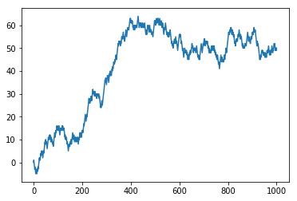

```python
plt.plot(range(1001),walking)
plt.show()
```

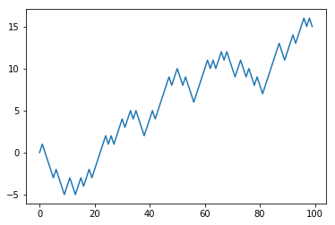

```python
plt.plot(range(100),walking[:100])
plt.show()
```

### numpy로 구현

- 1000개의 난수를 생성
- 누적합으로 계단 오르기를 구현

```python
rs=np.random.randint(0, 2, size=1000)
rs
```

```
array([0, 0, 1, 0, 0, 1, 0, 1, 1, 0, 1, 0, 0, 1, 0, 0, 1, 1, 0, 1, 1, 0,
       0, 0, 1, 0, 0, 0, 1, 1, 1, 1, 1, 1, 1, 0, 1, 1, 0, 0, 0, 1, 1, 0,
       1, 1, 0, 0, 0, 0, 1, 0, 1, 0, 1, 1, 0, 0, 0, 1, 1, 0, 1, 0, 1, 1,
       1, 0, 1, 0, 1, 0, 1, 0, 1, 0, 0, 1, 1, 1, 0, 0, 0, 1, 1, 1, 1, 1,
       0, 0, 0, 0, 0, 0, 1, 0, 0, 1, 0, 0, 0, 0, 1, 0, 0, 1, 0, 1, 0, 1,
       1, 0, 0, 0, 1, 0, 0, 0, 1, 0, 1, 1, 1, 1, 0, 0, 1, 0, 0, 0, 0, 1,
       1, 0, 0, 1, 0, 1, 1, 0, 0, 0, 0, 0, 0, 1, 0, 0, 1, 0, 0, 0, 1, 0,
       1, 0, 0, 0, 0, 1, 1, 1, 0, 0, 1, 0, 0, 0, 1, 0, 0, 0, 0, 1, 1, 0,
       1, 1, 1, 1, 0, 0, 1, 0, 0, 1, 1, 0, 1, 0, 1, 0, 0, 1, 0, 1, 1, 0,
       0, 1, 0, 0, 0, 0, 0, 1, 1, 1, 1, 1, 1, 0, 0, 1, 0, 0, 0, 1, 0, 0,
       0, 1, 0, 0, 0, 0, 0, 0, 1, 0, 0, 0, 0, 1, 0, 0, 0, 0, 0, 1, 1, 0,
       0, 1, 1, 0, 0, 1, 1, 0, 1, 0, 0, 1, 0, 0, 1, 1, 1, 0, 0, 0, 0, 0,
       0, 1, 1, 0, 1, 1, 0, 0, 0, 1, 1, 1, 0, 0, 1, 0, 0, 1, 0, 0, 1, 0,
       0, 1, 1, 1, 0, 1, 1, 1, 1, 0, 0, 1, 0, 1, 1, 0, 1, 1, 0, 1, 0, 0,
       0, 1, 0, 0, 1, 0, 0, 0, 0, 0, 0, 1, 0, 0, 0, 0, 1, 0, 0, 0, 1, 1,
```

[output cut: 31 more lines]

```python
step = np.where(rs == 1, rs, -1)
```

```python
# 최소 시작이 0부터 이다!!
# 최최값을 0으로 두고 시작
step[0] = 0
step
```

```
array([ 0, -1,  1, -1, -1,  1, -1,  1,  1, -1,  1, -1, -1,  1, -1, -1,  1,
        1, -1,  1,  1, -1, -1, -1,  1, -1, -1, -1,  1,  1,  1,  1,  1,  1,
        1, -1,  1,  1, -1, -1, -1,  1,  1, -1,  1,  1, -1, -1, -1, -1,  1,
       -1,  1, -1,  1,  1, -1, -1, -1,  1,  1, -1,  1, -1,  1,  1,  1, -1,
        1, -1,  1, -1,  1, -1,  1, -1, -1,  1,  1,  1, -1, -1, -1,  1,  1,
        1,  1,  1, -1, -1, -1, -1, -1, -1,  1, -1, -1,  1, -1, -1, -1, -1,
        1, -1, -1,  1, -1,  1, -1,  1,  1, -1, -1, -1,  1, -1, -1, -1,  1,
       -1,  1,  1,  1,  1, -1, -1,  1, -1, -1, -1, -1,  1,  1, -1, -1,  1,
       -1,  1,  1, -1, -1, -1, -1, -1, -1,  1, -1, -1,  1, -1, -1, -1,  1,
       -1,  1, -1, -1, -1, -1,  1,  1,  1, -1, -1,  1, -1, -1, -1,  1, -1,
       -1, -1, -1,  1,  1, -1,  1,  1,  1,  1, -1, -1,  1, -1, -1,  1,  1,
       -1,  1, -1,  1, -1, -1,  1, -1,  1,  1, -1, -1,  1, -1, -1, -1, -1,
       -1,  1,  1,  1,  1,  1,  1, -1, -1,  1, -1, -1, -1,  1, -1, -1, -1,
        1, -1, -1, -1, -1, -1, -1,  1, -1, -1, -1, -1,  1, -1, -1, -1, -1,
       -1,  1,  1, -1, -1,  1,  1, -1, -1,  1,  1, -1,  1, -1, -1,  1, -1,
       -1,  1,  1,  1, -1, -1, -1, -1, -1, -1,  1,  1, -1,  1,  1, -1, -1,
       -1,  1,  1,  1, -1, -1,  1, -1, -1,  1, -1, -1,  1, -1, -1,  1,  1,
        1, -1,  1,  1,  1,  1, -1, -1,  1, -1,  1,  1, -1,  1,  1, -1,  1,
       -1, -1, -1,  1, -1, -1,  1, -1, -1, -1, -1, -1, -1,  1, -1, -1, -1,
       -1,  1, -1, -1, -1,  1,  1,  1,  1,  1,  1, -1, -1,  1,  1, -1,  1,
        1, -1,  1,  1,  1, -1,  1, -1,  1, -1, -1, -1,  1,  1, -1,  1,  1,
        1, -1, -1,  1, -1,  1,  1,  1, -1, -1, -1, -1, -1,  1, -1, -1, -1,
       -1,  1,  1,  1, -1,  1, -1,  1, -1,  1,  1,  1,  1, -1, -1,  1,  1,
        1, -1, -1, -1,  1,  1, -1,  1,  1,  1, -1, -1,  1,  1, -1,  1,  1,
        1, -1,  1, -1,  1, -1, -1, -1,  1,  1, -1,  1, -1,  1,  1,  1,  1,
       -1, -1,  1, -1, -1, -1,  1, -1,  1, -1,  1, -1,  1,  1,  1, -1, -1,
        1, -1,  1, -1,  1,  1,  1, -1, -1,  1, -1, -1,  1,  1,  1, -1,  1,
       -1,  1, -1, -1, -1, -1,  1, -1,  1,  1,  1, -1, -1, -1,  1, -1, -1,
        1,  1, -1,  1,  1,  1, -1,  1,  1,  1, -1, -1,  1,  1,  1,  1,  1,
       -1, -1, -1, -1, -1, -1, -1,  1, -1, -1, -1,  1,  1,  1,  1,  1,  1,
        1, -1, -1,  1, -1,  1, -1,  1,  1,  1, -1,  1, -1,  1,  1, -1,  1,
        1,  1, -1,  1, -1, -1,  1,  1, -1, -1, -1,  1, -1,  1, -1, -1,  1,
        1,  1,  1,  1, -1, -1, -1,  1,  1,  1,  1, -1, -1,  1, -1, -1, -1,
       -1,  1, -1, -1, -1, -1, -1, -1, -1, -1,  1,  1, -1,  1, -1, -1, -1,
       -1, -1, -1, -1, -1,  1, -1,  1,  1, -1, -1,  1, -1, -1,  1,  1, -1,
       -1, -1, -1, -1, -1, -1, -1, -1, -1,  1,  1, -1, -1,  1, -1,  1, -1,
        1,  1,  1, -1,  1,  1,  1, -1,  1, -1, -1,  1,  1, -1,  1, -1, -1,
       -1,  1,  1, -1,  1,  1, -1, -1, -1,  1, -1, -1, -1,  1, -1,  1, -1,
       -1, -1,  1,  1,  1,  1,  1, -1,  1, -1, -1,  1,  1,  1, -1, -1, -1,
        1,  1, -1, -1,  1,  1, -1,  1, -1, -1,  1, -1, -1, -1, -1,  1, -1,
       -1, -1,  1, -1,  1,  1,  1,  1, -1, -1, -1,  1, -1, -1, -1,  1, -1,
        1,  1, -1,  1, -1,  1, -1, -1, -1, -1, -1,  1, -1,  1,  1,  1,  1,
        1,  1,  1, -1,  1, -1,  1, -1, -1, -1,  1, -1,  1, -1, -1,  1,  1,
        1, -1,  1, -1, -1,  1, -1,  1,  1, -1,  1,  1, -1, -1,  1,  1, -1,
       -1, -1, -1,  1, -1, -1, -1,  1,  1, -1, -1, -1,  1,  1,  1,  1,  1,
       -1,  1,  1,  1, -1,  1, -1, -1, -1,  1,  1,  1,  1,  1, -1, -1, -1,
       -1, -1, -1,  1, -1,  1, -1, -1,  1, -1,  1,  1,  1, -1, -1,  1, -1,
        1,  1, -1, -1, -1,  1,  1,  1, -1,  1, -1,  1, -1, -1,  1, -1, -1,
        1,  1, -1,  1, -1, -1, -1, -1,  1, -1,  1, -1,  1, -1, -1, -1, -1,
        1, -1,  1,  1, -1, -1, -1,  1, -1, -1, -1,  1,  1,  1, -1,  1, -1,
        1, -1, -1,  1, -1,  1, -1, -1, -1,  1,  1,  1, -1,  1,  1, -1,  1,
       -1,  1,  1, -1,  1,  1, -1, -1, -1, -1,  1,  1,  1, -1,  1,  1,  1,
        1,  1,  1, -1,  1,  1, -1, -1, -1,  1, -1,  1, -1,  1, -1,  1, -1,
       -1,  1, -1, -1, -1,  1,  1, -1, -1, -1, -1,  1,  1,  1,  1, -1,  1,
        1,  1, -1,  1,  1, -1,  1, -1,  1, -1,  1,  1, -1, -1, -1,  1,  1,
       -1,  1,  1, -1, -1, -1, -1,  1, -1,  1,  1,  1, -1,  1,  1, -1,  1,
       -1,  1, -1, -1,  1,  1,  1,  1,  1, -1, -1, -1,  1, -1, -1,  1, -1,
        1,  1,  1,  1,  1, -1, -1, -1,  1,  1, -1, -1, -1,  1,  1, -1,  1,
        1, -1, -1,  1,  1,  1,  1, -1,  1, -1, -1,  1, -1,  1])
```

```python
# 계단 오르기 => 누적합
walking = step.cumsum()
walking
```

```
array([  0,  -1,   0,  -1,  -2,  -1,  -2,  -1,   0,  -1,   0,  -1,  -2,
        -1,  -2,  -3,  -2,  -1,  -2,  -1,   0,  -1,  -2,  -3,  -2,  -3,
        -4,  -5,  -4,  -3,  -2,  -1,   0,   1,   2,   1,   2,   3,   2,
         1,   0,   1,   2,   1,   2,   3,   2,   1,   0,  -1,   0,  -1,
         0,  -1,   0,   1,   0,  -1,  -2,  -1,   0,  -1,   0,  -1,   0,
         1,   2,   1,   2,   1,   2,   1,   2,   1,   2,   1,   0,   1,
         2,   3,   2,   1,   0,   1,   2,   3,   4,   5,   4,   3,   2,
         1,   0,  -1,   0,  -1,  -2,  -1,  -2,  -3,  -4,  -5,  -4,  -5,
        -6,  -5,  -6,  -5,  -6,  -5,  -4,  -5,  -6,  -7,  -6,  -7,  -8,
        -9,  -8,  -9,  -8,  -7,  -6,  -5,  -6,  -7,  -6,  -7,  -8,  -9,
       -10,  -9,  -8,  -9, -10,  -9, -10,  -9,  -8,  -9, -10, -11, -12,
       -13, -14, -13, -14, -15, -14, -15, -16, -17, -16, -17, -16, -17,
       -18, -19, -20, -19, -18, -17, -18, -19, -18, -19, -20, -21, -20,
       -21, -22, -23, -24, -23, -22, -23, -22, -21, -20, -19, -20, -21,
       -20, -21, -22, -21, -20, -21, -20, -21, -20, -21, -22, -21, -22,
       -21, -20, -21, -22, -21, -22, -23, -24, -25, -26, -25, -24, -23,
       -22, -21, -20, -21, -22, -21, -22, -23, -24, -23, -24, -25, -26,
       -25, -26, -27, -28, -29, -30, -31, -30, -31, -32, -33, -34, -33,
       -34, -35, -36, -37, -38, -37, -36, -37, -38, -37, -36, -37, -38,
       -37, -36, -37, -36, -37, -38, -37, -38, -39, -38, -37, -36, -37,
       -38, -39, -40, -41, -42, -41, -40, -41, -40, -39, -40, -41, -42,
       -41, -40, -39, -40, -41, -40, -41, -42, -41, -42, -43, -42, -43,
       -44, -43, -42, -41, -42, -41, -40, -39, -38, -39, -40, -39, -40,
       -39, -38, -39, -38, -37, -38, -37, -38, -39, -40, -39, -40, -41,
       -40, -41, -42, -43, -44, -45, -46, -45, -46, -47, -48, -49, -48,
       -49, -50, -51, -50, -49, -48, -47, -46, -45, -46, -47, -46, -45,
       -46, -45, -44, -45, -44, -43, -42, -43, -42, -43, -42, -43, -44,
       -45, -44, -43, -44, -43, -42, -41, -42, -43, -42, -43, -42, -41,
       -40, -41, -42, -43, -44, -45, -44, -45, -46, -47, -48, -47, -46,
       -45, -46, -45, -46, -45, -46, -45, -44, -43, -42, -43, -44, -43,
       -42, -41, -42, -43, -44, -43, -42, -43, -42, -41, -40, -41, -42,
       -41, -40, -41, -40, -39, -38, -39, -38, -39, -38, -39, -40, -41,
       -40, -39, -40, -39, -40, -39, -38, -37, -36, -37, -38, -37, -38,
       -39, -40, -39, -40, -39, -40, -39, -40, -39, -38, -37, -38, -39,
       -38, -39, -38, -39, -38, -37, -36, -37, -38, -37, -38, -39, -38,
       -37, -36, -37, -36, -37, -36, -37, -38, -39, -40, -39, -40, -39,
       -38, -37, -38, -39, -40, -39, -40, -41, -40, -39, -40, -39, -38,
       -37, -38, -37, -36, -35, -36, -37, -36, -35, -34, -33, -32, -33,
       -34, -35, -36, -37, -38, -39, -38, -39, -40, -41, -40, -39, -38,
       -37, -36, -35, -34, -35, -36, -35, -36, -35, -36, -35, -34, -33,
```

[output cut: 23 more lines]

```
       -59, -60, -61, -62, -63, -62, -63, -62, -63, -62, -63, -64, -65,
       -66, -65, -66, -65, -64, -65, -66, -67, -66, -67, -68, -69, -68,
       -67, -66, -67, -66, -67, -66, -67, -68, -67, -68, -67, -68, -69,
       -70, -69, -68, -67, -68, -67, -66, -67, -66, -67, -66, -65, -66,
       -65, -64, -65, -66, -67, -68, -67, -66, -65, -66, -65, -64, -63,
       -62, -61, -60, -61, -60, -59, -60, -61, -62, -61, -62, -61, -62,
       -61, -62, -61, -62, -63, -62, -63, -64, -65, -64, -63, -64, -65,
       -66, -67, -66, -65, -64, -63, -64, -63, -62, -61, -62, -61, -60,
       -61, -60, -61, -60, -61, -60, -59, -60, -61, -62, -61, -60, -61,
       -60, -59, -60, -61, -62, -63, -62, -63, -62, -61, -60, -61, -60,
       -59, -60, -59, -60, -59, -60, -61, -60, -59, -58, -57, -56, -57,
       -58, -59, -58, -59, -60, -59, -60, -59, -58, -57, -56, -55, -56,
       -57, -58, -57, -56, -57, -58, -59, -58, -57, -58, -57, -56, -57,
       -58, -57, -56, -55, -54, -55, -54, -55, -56, -55, -56, -55],
      dtype=int32)
```

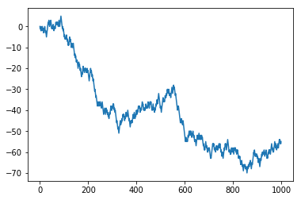

```python
plt.plot(range(1000),walking)
```

```python
# 최초 위치에서 15계단 이상 떨어진 최초 위치
(np.abs(walking)>=15).argmax()
```

```
147
```

```python
# 1000씩 계단 오르는 데이터를 5000번 수행한다.(5000개를 모은다.)
rs = np.random.randint(0, 2, size = (5000,1000))
print(rs.shape, rs.ndim, rs.dtype)
```

```
(5000, 1000) 2 int32
```

```python
step = np.where( rs > 0, rs, -1)
```

```python
walking  = step.cumsum(axis = 1)
walking.shape
walking
```

```
array([[  1,   0,  -1, ..., -10, -11, -10],
       [  1,   2,   1, ...,   4,   3,   4],
       [  1,   2,   3, ..., -38, -39, -38],
       ...,
       [ -1,  -2,  -3, ...,  -6,  -5,  -4],
       [ -1,   0,   1, ..., -58, -57, -58],
       [  1,   0,  -1, ..., -24, -23, -22]], dtype=int32)
```

```python
print(walking.max(), walking.min())
```

```
135 -124
```

```python
# 크기가 최초 위치에서 30이상 이동한 갯수
overStep = (np.abs(walking) >= 30).any(1)
print( len(overStep), overStep)
```

```
5000 [False False  True ...  True  True  True]
```

```python
overStep.sum()
```

```
3380
```